# 流行歌曲歌詞的流量密碼

## 作者：凃昱辰

流行歌曲常是國人日常生活中不可或缺的一部分，無論老少都能從流行歌曲中找到共鳴和情感宣洩的出口。那麼究竟是什麼特質讓流行歌「流行」呢？這些特質是否會跟演唱者的性別、人數多寡有關呢？又或者這些特質的影響會隨時間變化？本專案將以華語歌曲的歌詞切入，探討以下三點：

第一：歌曲發行年代在不同演唱者性別與人數的分布情形。

第二：男女歌手或團體在不同時代的熱門歌曲字數是否不同？

最後：男女歌手或團體的熱門歌曲哪些字的使用比率最高？同時也會細究特定詞彙的使用情形。

## 目錄

- 資料取得與處理
- 分析項目與結果
  - 分析一：歌曲發行年代在不同演唱者性別與人數的分布情形
    - 小結1
  - 分析二：男女歌手或團體在不同時代的熱門歌曲字數是否不同？
    - 小結2
  - 分析三：男女歌手或團體的熱門歌曲哪些字的使用比率最高？與特定詞彙的使用情形
    - 小結3-1
    - 小結3-2
- 結論
  - 商業洞見
- 參考資料

## 資料取得與處理

本專案以Python為主要工具，會去魔鏡歌詞網熱門歌曲的網址[1]抓取其中的男生、女生、團體共三類熱門歌曲的歌詞網址，三類各100首熱門歌曲，總共300首。接著會從歌曲歌詞的網站爬取（1）歌詞內容、（2）該歌曲的專輯網址。再來從專輯網址爬取發行年代的資訊。計算詞數與分析特定詞彙的部分會使用中研院的斷詞套件CkipTagger[2]進行斷詞。繪圖的部分則是使用Plotnine套件[3]繪圖。資料清理與視覺化的細節詳見附錄程式碼的部分。

## 分析項目與結果

### 分析一：歌曲發行年代在不同演唱者性別與人數的分布情形

[figure not shown]

#### 小結1

從上圖可知，男女歌手與團體熱門歌曲的分佈雷同，大約2016年前後歌曲各佔50%，大約2020~2021年後的歌曲佔25%，大約2010年前的歌曲佔25%。如預期，新發行的歌會占了熱門歌曲中的一部份，但是也可以看到，在經典歌曲上，即便超過10年、15年也依舊流行。

### 分析二：男女歌手或團體在不同時代的熱門歌曲字數是否不同？

[figure not shown]

#### 小結2

在散佈圖當中趨勢較不明顯，但是若是將年代平均拆分成三等份，並依男女歌手或團體計算不同時代的字數平均來繪製折線圖，可以看到熱門歌曲的字數的偏好變化：聽眾偏好的歌曲字數會依歌手是男歌手、女歌手、或是團體而有不同，而且圖中也顯示熱門歌曲字數偏好會隨時間的改變，團體熱門歌曲的偏好字數逐年下降，女歌手的熱門歌曲字數先升後降，男歌手的熱門歌曲字數則是逐年上升。

### 分析三：男女歌手或團體的熱門歌曲哪些字的使用比率最高？與特定詞彙的使用情形

當中會排除各種標點符號，而且詞類會選取內容詞：動詞、名詞、形容詞，以避免結果都是「了」、「的」等已文法功能為主、較無實體意義的虛詞。

[figure not shown]

從上圖中可以看到，常用的詞彙有：我、你、想、說、我們、心、愛等等...在三個類別都差不多。因此接下來會針對特定詞彙（你、我、想、我們、自己、愛）比較男歌手、女歌手、團體使用比例的不同。當中男歌手「妳」的使用率會合併到「你」的使用率當中。

[figure not shown]

#### 小結3-1

從上圖可以看到：「你」的使用團體最少，男歌手多於女歌手的熱門歌曲。「想」的使用女歌手最少，男歌手最多，團體次之。「愛」的使用男歌手多於女歌手與團體。「我」的使用在三個類別都差不多，唯獨女歌手稍少。「我們」的使用男歌手多於女歌手與團體。「自己」的使用團體沒有，女歌手多於男歌手。由此可知，聽眾偏好男歌手為「你」的「想」、「愛」的情感，同時也喜歡男歌手對於「我們」的描述。而聽眾對於女歌手則是偏好其指涉到「自己」。\ 因為中文是非常注重字序的語言，例如「我愛你」與「你愛我」意思完全不同，因此為了多瞭解字的使用情境，接下來會計算「愛」的連續n個詞（n-gram）前15名，其中會針對n = 2與n = 3來看，以n = 2為主，n = 3為輔助詮釋。

[figure not shown]

#### 小結3-2

從上圖中可以看到，不管是男女歌手或團體，常用的連續2個詞有：愛我、愛你、愛的、愛情、愛過、愛上等等，連續3個詞則多是連續2個詞的延伸。其中比較值得注意的是：團體、男歌手的熱門歌曲使用「愛你」最多，女歌手的熱門歌曲則使用「愛我」最多。也印證上文的小結：聽眾對男歌手較喜歡其呈現「愛你」的情感，而對女歌手則是偏好其指涉到自己，因此「愛我」最多。

## 結論

本專案針對華語熱門歌曲的歌詞進行文本分析與視覺化，發現了歌曲發行年代在團體與男女歌手的熱門歌曲大約有一半為近8年的歌曲，另一半為超過8年的歌，顯示部分老歌歷久不衰的特性。其中在不同時代的熱門歌曲在男女歌手或團體的類別上字數變化有所不同：團體的字數隨時代演進越來越少，男歌手的字數越來越多，女歌手的字數在過去越來越多，但到了近代則越來越少。針對個別詞彙的分析上，則是發現「你」、「我」、「想」、「我們」、「自己」、「愛」等六個詞在男女歌手或團體的熱門歌曲中使用比率有所不同，尤其是聽眾對於男歌手偏好對「你」表達「想」、「愛」的情感，對女歌手則是偏好指涉「自己」的敘述。最後也細究「愛」在熱門歌曲中的使用情境：發現團體與男歌手傾向使用「愛你」，女歌手則多使用「愛我」。本研究只針對華語歌曲，以及特定的幾個詞會做分析，未來的研究可以多納入其他語言的熱門歌曲，如英語與日語，同時也可以再對「愛」以外的其他做進一步的分析，如「想」或「看」等，讓我們可以對熱門歌曲的歌詞的特質有更全面的了解，可作為寫詞人的參考。

### 商業洞見

本專案的發現也可以提供一些商業上的建言，例如：（1）對不同的族群客製化行銷訊息，如強調「你」可以觸擊較廣泛的群眾、強調「我」則帶有個人風格；（2）做出市場區隔，使用在廣告或產品介紹當中，針對男性強調對待或照顧他人的情感，針對女性則著重呈現出照顧自己的訊息。

## 參考資料

[1] https://mojim.com/twzhot-song.htm

[2] https://github.com/ckiplab/ckiptagger

[3] https://plotnine.org/

## 附錄：程式碼

### 爬蟲、資料收集與整理

```python
import requests
from bs4 import BeautifulSoup
import re
import pandas as pd

class MojimCrawler:
    def __init__(self, base_url='https://mojim.com'):
        self.base_url = base_url

    def fetch_page(self, url):
        response = requests.get(url)
        return BeautifulSoup(response.text, 'html.parser')

    def extract_hrefs_with_two_xes(self, section_strong):
        #抓取魔鏡歌詞網熱門歌曲(只抓其中的男生、女生、團體)的網址
        #只會抓到部分，如'/twy235489x19x1.htm'，會在後面的函式加上'https://mojim.com'，才會是正確的網址
        hrefs = []
        count = 0

        if section_strong:
            for tr_tag in section_strong.find_all_next('tr'):
                for a_tag in tr_tag.find_all('a', href=True):
                    href = a_tag.get('href', '')
                    if href.count('x') == 2:
                        hrefs.append(href)
                        count += 1
                        if count == 100: # 只要前100個，避免抓到其他雜訊
                            return hrefs
        return hrefs

    def songtoalbum(self, url):
        #從歌曲歌詞的網站找出專輯網址
        #去除y，以及第2個'x'(含)到'.htm'(不含)之前的文字
        #'http://mojim.com/twy235489x19x1.htm' → 'http://mojim.com/tw235489x19.htm'

        url = url.replace('y', '')
        last_x_index = url.rfind('x')
        htm_index = url.find('.htm')
        if last_x_index != -1 and htm_index != -1:
            return url[:last_x_index] + url[htm_index:]
        else:
            return url

    def albumyear(self, url):
        #爬取專輯發行年代

        try:
            soup = self.fetch_page(url)
            h2_tag = soup.find('h2')
            if h2_tag:
                h2_text = h2_tag.get_text(strip=True)
                match = re.search(r'\d{4}', h2_text)
                if match:
                    return match.group()
            return None
        except Exception as e:
            print(f"Error occurred while processing URL: {url}")
            print(e)
            return None

    def lyrics_start(self, parent_dl):
        #找出歌詞的開始，在html當中第二個<br/><br/>後，後接一個至二個<br/>
        try:
            parent_string = str(parent_dl)
            pattern = r'<br/><br/>(.*?)<br/>.*?<br/>'
            matches = re.findall(pattern, parent_string, re.DOTALL)
            extracted_texts = [match.strip() for match in matches]
            return extracted_texts[1]
        except:
            #若歌詞不在html當中第二個<br/><br/>後，則回傳NaN，之後的應用會使用try-except來跳過
            return float('nan')

    def extract_lyrics_info(self, soup, url):
        #爬蟲：歌詞
        song_element = soup.find('dt', class_='fsZx2')
        if song_element:
            song = song_element.get_text(strip=True)
            parent_dl = song_element.find_parent('dl', class_='fsZx1')
            if parent_dl:
                parent_text = parent_dl.get_text(separator=' ', strip=True)
                parts = parent_text.split(' ')

                # 抓取歌手名字 (第一個元素)
                singer = parts[0].strip()

                #使用自訂函數lyrics_start()找出歌詞開始的句子
                substring = self.lyrics_start(parent_dl)
                # 進行部分前處理
                #若有start裡面的詞彙開頭，因非歌詞而不取出
                start = ['作詞', '作曲', '編曲', '演唱：', '[', '電吉他', '貝斯', '鼓', '鋼琴:', '打擊樂', 'Organ',
                         '口琴', '和聲', '錄音師', '混音師', '錄音室', '錄音助理', '母帶工程室', '母帶工程師', '封面設計',
                         '配唱人', '協力配唱', 'Editing', '人：', '混音工程師', '母帶工程師', 'OP：', 'SP：',
                         '♀呆呆ａ豪♂','製作：','Rap詞','製作人：', '吉他：']
                #若有skip裡面的詞彙，因非歌詞而不取出
                skip = ['在', '※', 'Mojim.com\u3000魔鏡歌詞網','※Http://www.mojim.com','魔鏡歌詞網',
                        '<間奏>','間奏','男：','女：','合：','Trzcinski','Merrill', 'Sound' ,'♀呆呆ａ豪♂',
                       'Teo','單依純','林俊傑','鄧紫棋','更多更詳盡歌詞']
                skip.append(singer)

                #如果有以下詞彙，以下詞彙以前的內容都不要
                index_to_keep = next((i for i, item in enumerate(parts) if item.startswith("作曲：")), None)
                if index_to_keep is not None:
                    parts = parts[index_to_keep:]
                index_to_keep = next((i for i, item in enumerate(parts) if item.startswith("作詞：")), None)
                if index_to_keep is not None:
                    parts = parts[index_to_keep:]

                #若有start裡面的詞彙開頭，因非歌詞而不取出
                parts = [item for item in parts if not any(item.startswith(prefix) for prefix in start)]
                #若有skip裡面的詞彙，因非歌詞而不取出
                parts = [item for item in parts if item not in skip]

                #如果有以下文字，以下文字以後的內容都不要
                index = next((i for i, x in enumerate(parts) if x == '感謝'), None)
                if index is not None:
                    parts = parts[:index]
                index_to_keep = next((i for i, item in enumerate(parts) if item.startswith("edit")), None)
                if index_to_keep is not None:
                    parts = parts[:index_to_keep]
                index_to_keep = next((i for i, item in enumerate(parts) if item.startswith("-----")), None)
                if index_to_keep is not None:
                    parts = parts[:index_to_keep]
                index_to_keep = next((i for i, item in enumerate(parts) if item.startswith("[")), None)
                if index_to_keep is not None:
                    parts = parts[:index_to_keep]

                lyrics = ' '.join(parts)

                #使用上面的substring = lyrics_start(parent_dl)的結果當保險
                try:
                    index = lyrics.index(substring)
                    lyrics = lyrics[index:]
                except:
                    pass

                #使用自訂函數songtoalbum()找出專輯網址
                albumweb = self.songtoalbum(url)
                #使用自訂函數albumyear()找出專輯年代
                year = self.albumyear(albumweb)

                #建立表格
                data = {'Singer': [singer], 'Song': [song], 'Year': [year], 'Lyrics': [lyrics]}
                return pd.DataFrame(data)
            else:
                return None
        else:
            return None

    def crawl(self, urls):
        #組合網址，並爬取
        complete_urls = [self.base_url + url for url in urls]
        dfs = []

        for url in complete_urls:
            soup = self.fetch_page(url)
            df = self.extract_lyrics_info(soup, url)
            if df is not None:
                dfs.append(df)

        # 合併所有表格
        final_df = pd.concat(dfs, ignore_index=True)
        return final_df

    def run(self):
        #熱門歌曲頁的網址
        url = 'https://mojim.com/twzhot-song.htm'
        soup = self.fetch_page(url)

        #熱門歌曲的網址
        male_section = soup.find('strong', string='　歌曲排行 < 男生 >')
        male_hrefs = self.extract_hrefs_with_two_xes(male_section)

        female_section = soup.find('strong', string='　歌曲排行 < 女生 >')
        female_hrefs = self.extract_hrefs_with_two_xes(female_section)

        group_section = soup.find('strong', string='　歌曲排行 < 團體 >')
        group_hrefs = self.extract_hrefs_with_two_xes(group_section)

        #建立表格
        male_songs = self.crawl(male_hrefs)
        female_songs = self.crawl(female_hrefs)
        group_songs = self.crawl(group_hrefs)

        #人工清理歌詞
        male_songs = self.clean_lyrics(male_songs, 'male')
        female_songs = self.clean_lyrics(female_songs, 'female')
        group_songs = self.clean_lyrics(group_songs, 'group')

        #填入空缺的年代
        male_songs = self.fill_years(male_songs, 'male')
        female_songs = self.fill_years(female_songs, 'female')
        group_songs = self.fill_years(group_songs, 'group')

        #輸出成csv檔
        male_songs.to_csv("male_songs.csv", index=False)
        female_songs.to_csv("female_songs.csv", index=False)
        group_songs.to_csv("group_songs.csv", index=False)
        return male_songs, female_songs, group_songs

    def clean_lyrics(self, df, category):
        #檢視資料後，將不要的字串部分移除
        #排名會定時更新，因此使用try & except，避免該歌曲不在榜單當中
        #以下是執行當下檢查出的部分
        cleaning_steps = {
            'male': [
                {"Song": "童話", "to_replace": "Nakamura 年 1 月 21 日"},
                {"Song": "黃昏", "to_replace": "- 黃昏 ※Http://www.mojim.com　魔鏡歌詞網"},
                {"Song": "在迦納共和國離婚", "to_replace": "鋼琴 : 林言奕 Andy Lin/姚逸軒 Captain Yao : 林言奕 Andy Lin Captain Yao Vocal Andy Lin Andy Lin @上奕音樂 Andy Lin Andy Lin Music (M) Sdn Bhd Music Publishing (M) Sdn Bhd"},
                {"Song": "雪落下的聲音", "to_replace": "延禧攻略 片尾曲"},
                {"Song": "孤勇者", "to_replace": "(《英雄聯盟：雙城之戰》動畫劇集中文主題曲) -"}
            ],
            'female': [
                {"Song": "最後一頁", "to_replace": "年 9 月 10 日"},
                {"Song": "你", "to_replace": "- David碧咸 QQ 370974323"},
                {"Song": "心牆", "to_replace": "- 心牆 MONTH M'S 製作 ~*"},
                {"Song": "夏天的風", "to_replace": "＊,＃,＃ 年 7 月 6 日"},
                {"Song": "約定", "to_replace": "※Mojim.com　魔鏡歌詞網"}
            ],
            'group': [
                {"Song": "乾杯", "to_replace": "(MV版包括原次共7次) 弦樂編寫：于京延+李琪 弦樂演奏：李琪北京室內樂團 沖繩三弦：REI(Spoon de chop) 合唱：強辯+阿邦+小凱+阿沚"},
                {"Song": "我知道", "to_replace": "QQ：253057646"},
                {"Song": "離歌", "to_replace": "Il Sang 年 4 月 11 日"},
                {"Song": "浪流連", "to_replace": "LOW LUXE(歡迎訂閱)★"}
            ]
        }

        for step in cleaning_steps.get(category, []):
            try:
                new_lyrics = df[df['Song'] == step['Song']].iloc[0]['Lyrics'].replace(step['to_replace'], '')
                df.loc[df['Song'] == step['Song'], 'Lyrics'] = new_lyrics
            except:
                pass

        return df

    def fill_years(self, df, category):
        #部分專輯年代魔鏡網站沒有該資訊，需要自己上網找年代填入
        fill_values = {
            'male': [
                {"Singer": "林俊傑", "Song": "江南", "Year": 2004},
                {"Singer": "倫桑", "Song": "小蠻腰", "Year": 2015},
                {"Singer": "周深", "Song": "大魚", "Year": 2016},
                {"Singer": "寒洛", "Song": "達拉崩吧", "Year": 2017},
                {"Singer": "成龍", "Song": "男子漢", "Year": 1998},
                {"Singer": "韓安旭", "Song": "不在", "Year": 2016},
                {"Singer": "虎二", "Song": "你一定要幸福", "Year": 2018}
            ],
            'female': [
                {"Singer": "曾沛慈", "Song": "一個人想著一個人", "Year": 2013},
                {"Singer": "王一佳", "Song": "李白的酒杜甫的愁", "Year": 2024}
            ],
            'group': [
                {"Singer": "夢飛船", "Song": "不值得", "Year": 2000},
                {"Singer": "法鼓山", "Song": "大悲咒", "Year": 1989},
                {"Singer": "BY2", "Song": "有點甜(& 汪蘇瀧)", "Year": 2012},
                {"Singer": "蘇打綠", "Song": "當我們一起走過", "Year": 2011},
                {"Singer": "讚美之泉", "Song": "能不能", "Year": 2015}
            ]
        }

        for entry in fill_values.get(category, []):
            try:
                df.loc[(df['Singer'] == entry['Singer']) & (df['Song'] == entry['Song']), 'Year'] = entry['Year']
            except:
                pass

        return df
```

```python
# Usage
crawler = MojimCrawler()
male, female, group = crawler.run()
```

```python
# 轉換 'Year' 的格式為int64
# 新增欄位"男歌手"
male['Year'] = male['Year'].astype('int64')
male['Category'] = "男歌手"
male.info()
```

```
<class 'pandas.core.frame.DataFrame'>
RangeIndex: 100 entries, 0 to 99
Data columns (total 5 columns):
 #   Column    Non-Null Count  Dtype
---  ------    --------------  -----
 0   Singer    100 non-null    object
 1   Song      100 non-null    object
 2   Year      100 non-null    int64
 3   Lyrics    100 non-null    object
 4   Category  100 non-null    object
dtypes: int64(1), object(4)
memory usage: 4.0+ KB
```

```python
male['Year'].describe()
```

```
count     100.00000
mean     2015.31000
std         7.73774
min      1989.00000
25%      2008.00000
50%      2017.50000
75%      2022.00000
max      2024.00000
Name: Year, dtype: float64
```

```python
# 轉換 'Year' 的格式為int64
# 新增欄位"女歌手"
female['Year'] = female['Year'].astype('int64')
female['Category'] = "女歌手"
female.info()
```

```
<class 'pandas.core.frame.DataFrame'>
RangeIndex: 100 entries, 0 to 99
Data columns (total 5 columns):
 #   Column    Non-Null Count  Dtype
---  ------    --------------  -----
 0   Singer    100 non-null    object
 1   Song      100 non-null    object
 2   Year      100 non-null    int64
 3   Lyrics    100 non-null    object
 4   Category  100 non-null    object
dtypes: int64(1), object(4)
memory usage: 4.0+ KB
```

```python
female['Year'].describe()
```

```
count     100.000000
mean     2015.760000
std         7.514457
min      1989.000000
25%      2009.750000
50%      2017.500000
75%      2022.250000
max      2024.000000
Name: Year, dtype: float64
```

```python
# 轉換 'Year' 的格式為int64
# 新增欄位"團體"
group['Year'] = group['Year'].astype('int64')
group['Category'] = "團體"
group.info()
```

```
<class 'pandas.core.frame.DataFrame'>
RangeIndex: 100 entries, 0 to 99
Data columns (total 5 columns):
 #   Column    Non-Null Count  Dtype
---  ------    --------------  -----
 0   Singer    100 non-null    object
 1   Song      100 non-null    object
 2   Year      100 non-null    int64
 3   Lyrics    100 non-null    object
 4   Category  100 non-null    object
dtypes: int64(1), object(4)
memory usage: 4.0+ KB
```

```python
group['Year'].describe() #發現最小值異常
```

```
count     100.00000
mean     2008.21000
std        58.09315
min      1440.00000
25%      2009.00000
50%      2016.00000
75%      2020.00000
max      2024.00000
Name: Year, dtype: float64
```

```python
#檢查異常值
group[group['Year'] == 1440]
```

|  | Singer | Song | Year | Lyrics | Category |
| --- | --- | --- | --- | --- | --- |
| 78 | TNT時代少年團 | 愛到1440 | 1440 | 宋亞軒： 第一眼再沒有比這美的童話 第二眼心漏半拍是什麼說法 很快沒有掙扎 丁程鑫： TNT... | 團體 |

```python
#自行填入正確的值
group.loc[(group['Singer'] == 'TNT時代少年團') & (group['Song'] == '愛到1440'), 'Year'] = 2020
```

```python
group['Year'].describe()
```

```
count     100.000000
mean     2014.010000
std         8.999994
min      1983.000000
25%      2009.750000
50%      2016.000000
75%      2020.000000
max      2024.000000
Name: Year, dtype: float64
```

```python
#合併三個類別
all = pd.concat([male, female], ignore_index=True)
all = pd.concat([all, group], ignore_index=True)
all.to_csv("all_songs", index=False)
```

# 開始繪圖

```python
from plotnine import *
from plotnine.data import *
import numpy as np
import pandas as pd
import matplotlib.font_manager as fm
# Create font objects
kai = fm.FontProperties(fname='C:/Windows/Fonts/kaiu.ttf')
lobster = fm.FontProperties(fname='C:/myfont/Lobster/Lobster-Regular.ttf')
noto = fm.FontProperties(fname='C:/myfont/Noto_Sans_TC/static/NotoSansTC-Regular.ttf')
newroman = fm.FontProperties(fname='C:/Windows/Fonts/times.ttf')
```

### 第一點：歌曲發行年代在不同演唱者性別與人數的分布情形。

### 繪製盒狀圖

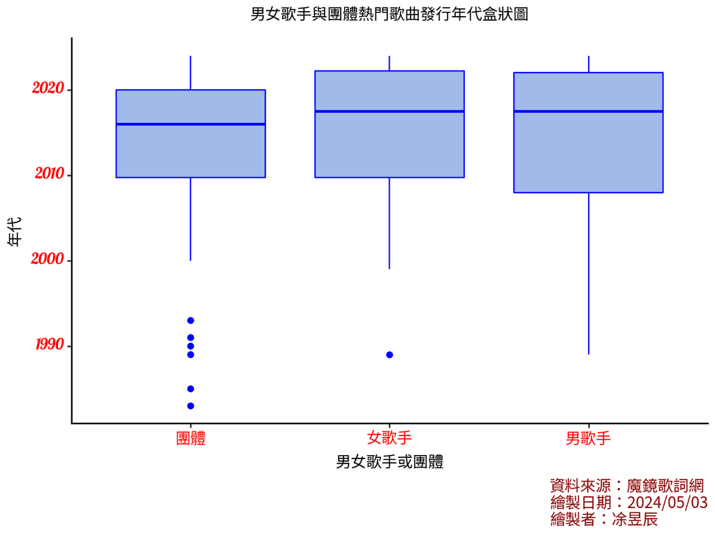

```
<Figure Size: (640 x 480)>
```

```python
fig1 = ggplot(all, aes('Category', 'Year')) +\
  geom_boxplot(color='blue',fill='#799ce0',alpha=0.7) +\
  labs(title = '男女歌手與團體熱門歌曲發行年代盒狀圖',
      x='男女歌手或團體',
      y='年代',
      caption='資料來源：魔鏡歌詞網\n繪製日期：'+pd.Timestamp("today").strftime("%Y/%m/%d")
      +'\n繪製者：凃昱辰')  +\
  theme_classic() +\
  theme(text=element_text(fontproperties=noto),
       plot_title=element_text(fontproperties=noto,color='black',ha='center'),
       axis_title=element_text(fontproperties=noto,color='black'),
       axis_text_y=element_text(fontproperties=lobster,color='red'),
       axis_text_x=element_text(fontproperties=noto,color='red'),
       plot_caption=element_text(fontproperties=noto,color='darkred',size=10,linespacing=1))
fig1
```

### 第二點：男女歌手或團體在不同時代的熱門歌曲字數是否不同？

### 使用ckiptagger斷詞系統

```python
#需使用(base)才能開
# 引入 CkipTagger 套件中的斷詞(WS)、詞性標註(POS)、命名實體識別(NER)工具，
# 以及資料下載與詞典建構函數
from ckiptagger import data_utils, construct_dictionary, WS, POS, NER

# 下載 CkipTagger 的預訓練模型，下載的路徑為"./"，並且生出data資料夾
#已下載過則不須執行以下此行
#data_utils.download_data_gdown("./")

# 初始化 WS(斷詞)、POS(詞性標註)、NER(命名實體識別) 的工具，模型路徑為 "./data"
ws = WS("./data")
pos = POS("./data")
#ner = NER("./data")
```

```python
#太新的tensorflow會不能跑CkipTagger
import tensorflow as tf
import keras
print(tf.__version__)
print(keras.__version__)
#2.12.0是執行專案當下可以直接使用pip install tensorflow的最舊版本
```

### 自訂函數：清理符號、詞彙記數

```python
from ckiptagger import WS
import re

#清理符號
def clean_segmented_words(words):
    unwanted_symbols = [
        ' ', '+', '.', '!', '/', '_', ',', '$', '%', '^', '*', '(', ')', '"', ']', '|', '—',
        '！', '，', '。', '？', '、', '~', '@', '#', '￥', '%', '……', '&', '*', '（', '）', '：',
        '；', '《', '》', '“', '”', '(', ')', '»', '〔', '〕', '-', '·'
    ]

    cleaned_words = [word for word in words if word not in unwanted_symbols]

    return cleaned_words

#詞彙記數
def word_count(text):
    # 用 CKIP-Tagger 斷詞
    segmented_words = ws([text])[0]  # 要用[]才能正確斷詞，而且要取第0個元素

    # 用自訂函數排除符號
    cleaned_words = clean_segmented_words(segmented_words)

    # 文字計數
    word_count = len(cleaned_words)

    return word_count
```

```python
#新增欄位'word_count'，應用word_count
all['word_count'] = all['Lyrics'].apply(word_count)
```

```python
all['word_count'].head()
```

```python
#檢查資料
all['word_count'].describe() #最大值、最小值要檢查
```

```
count     300.000000
mean      295.110000
std       156.535243
min        20.000000
25%       213.750000
50%       275.500000
75%       340.250000
max      2103.000000
Name: word_count, dtype: float64
```

```python
all[all['word_count'] == 20] #不改動
```

[output not shown]

```python
all[all['word_count'] == 2103] #不改動
```

[output not shown]

#### 對Year欄位的數量做3等分的切割，並命名老歌、介於中間、新歌

```python
# 新增欄位，對Year欄位的數量做3等分的切割，並命名
all['Time'] = pd.qcut(all['Year'],3,labels=['老歌','介於中間','新歌'])
```

```python
#檢查資料
all['Time'].value_counts()
```

```
Time
介於中間    103
老歌      100
新歌       97
Name: count, dtype: int64
```

```python
#檢查資料
all['Year'].describe()
```

```
count     300.000000
mean     2015.026667
std         8.117405
min      1983.000000
25%      2009.000000
50%      2017.000000
75%      2022.000000
max      2024.000000
Name: Year, dtype: float64
```

```python
#針對'Category','Time'做平均
all_time_slope = (all[['Category','Time','word_count']]
                    .groupby(['Category','Time'],observed=False)
                    .agg('mean')
                    .reset_index())
all_time_slope
```

|  | Category | Time | word_count |
| --- | --- | --- | --- |
| 0 | 團體 | 老歌 | 337.342857 |
| 1 | 團體 | 介於中間 | 331.853659 |
| 2 | 團體 | 新歌 | 278.458333 |
| 3 | 女歌手 | 老歌 | 262.757576 |
| 4 | 女歌手 | 介於中間 | 305.000000 |
| 5 | 女歌手 | 新歌 | 263.179487 |
| 6 | 男歌手 | 老歌 | 276.468750 |
| 7 | 男歌手 | 介於中間 | 283.588235 |
| 8 | 男歌手 | 新歌 | 308.029412 |

### 繪製斜坡圖

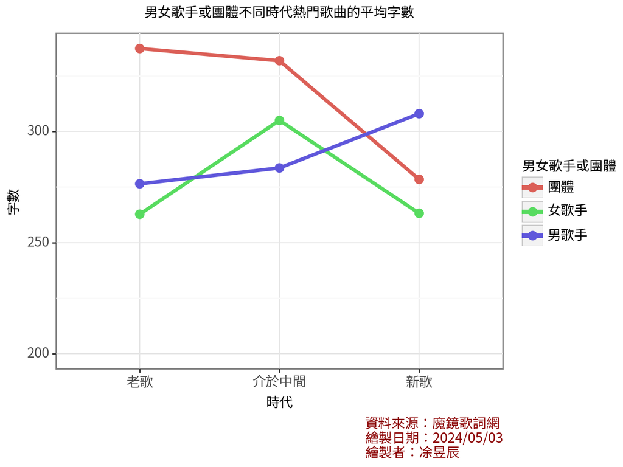

```
<Figure Size: (640 x 480)>
```

```python
fig2 =ggplot(all_time_slope, aes(x='Time',y='word_count',group='Category')) +\
  geom_line(aes(color='Category'),size=1.5) +\
  geom_point(aes(color='Category'),size=3)+\
  scale_y_continuous(limits=(200, None))+\
  labs(title='男女歌手或團體不同時代熱門歌曲的平均字數',
       x='時代',
       y='字數',
       color='男女歌手或團體',
       caption='資料來源：魔鏡歌詞網\n繪製日期：'+pd.Timestamp("today").strftime("%Y/%m/%d")
      +'\n繪製者：凃昱辰')  +\
  theme_bw() +\
  theme(text=element_text(fontproperties=noto),
       plot_title=element_text(fontproperties=noto, ha='center'),
       plot_caption=element_text(fontproperties=noto,color='darkred',size=10,linespacing=1))
fig2
```

### 繪製散佈圖

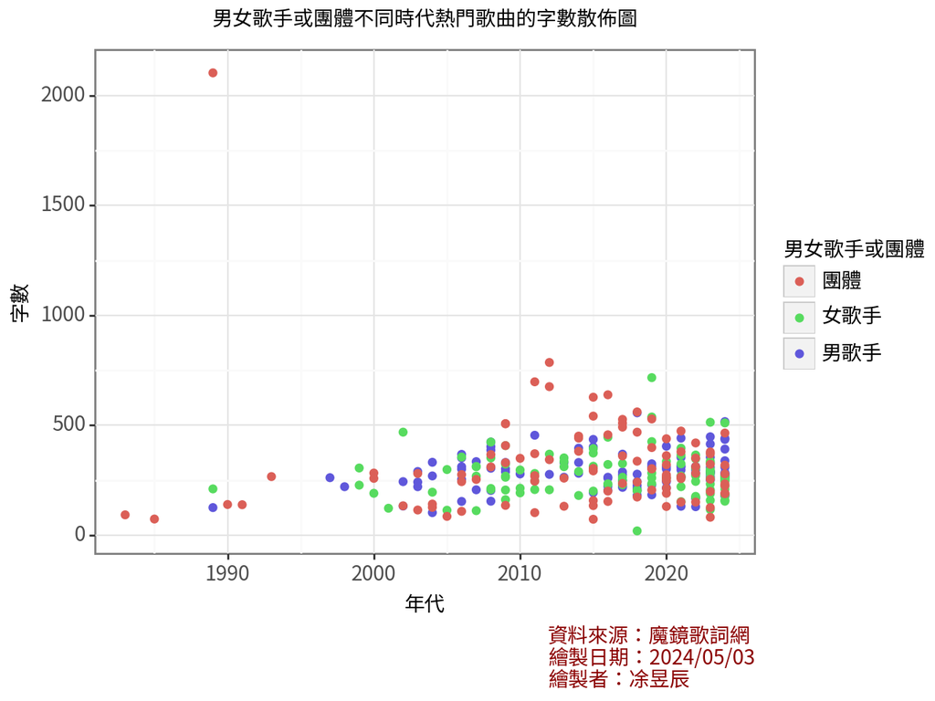

```
<Figure Size: (640 x 480)>
```

```python
fig3 = ggplot(all, aes(x='Year', y='word_count',color='Category')) +\
    geom_point()+\
  labs(title='男女歌手或團體不同時代熱門歌曲的字數散佈圖',
       x='年代',
       y='字數',
       color='男女歌手或團體',
       caption='資料來源：魔鏡歌詞網\n繪製日期：'+pd.Timestamp("today").strftime("%Y/%m/%d")
      +'\n繪製者：凃昱辰')  +\
  theme_bw() +\
  theme(text=element_text(fontproperties=noto),
       plot_title=element_text(fontproperties=noto, ha='center'),
       plot_caption=element_text(fontproperties=noto,color='darkred',size=10,linespacing=1))
fig3
```

### 第三點：男女歌手或團體的熱門歌曲哪些字的使用比率最高？

### 選取內容詞：動詞、名詞、形容詞。避免結果都是了、的等虛詞

### 自訂函數：清理符號、選取內容詞、斷詞歌詞

```python
import pandas as pd
from collections import Counter

#清理符號
def clean_segmented_words(words):
    unwanted_symbols = [
        ' ', '+', '.', '!', '/', '_', ',', '$', '%', '^', '*', '(', ')', '"', ']', '|', '—',
        '！', '，', '。', '？', '、', '~', '@', '#', '￥', '%', '……', '&', '*', '（', '）', '：',
        '；', '《', '》', '“', '”', '(', ')', '»', '〔', '〕', '-', '·'
    ]

    cleaned_words = [word for word in words if word not in unwanted_symbols]

    return cleaned_words

# 篩選特定詞類
def content_words(text):
    # 斷詞
    segmented_words = ws([text])[0]

    # 清理符號
    cleaned_words = clean_segmented_words(segmented_words)

    # 取得詞類
    segmented_words_pos = pos([segmented_words])[0]

    # 內容詞的詞類
    allowed_pos_tags = ["Na", "Nb", "Nc", "Nv","Nd", "VA", "VB", "VC", "Nh", "A", "VAC", "VCL",
                        "VD", "VF", "VE", "VG", "VH", "VHC", "VI", "VJ", "VK"]

    # 只篩選特定詞類
    filtered_words=[]
    for n, i in enumerate(segmented_words_pos):
        if i in allowed_pos_tags:
            filtered_words.append(segmented_words[n])
    content_words = ' '.join(filtered_words)
    return content_words

# 斷詞
def segment_lyrics(lyrics):
    # 斷詞
    word_segmented = ws([lyrics], sentence_segmentation=True)
    # 用' ' 連結文字
    segmented_text = ' '.join(word_segmented[0])
    return segmented_text
```

```python
#新增欄位'Segmented_Lyrics'，應用content_words
all['Segmented_Lyrics'] = all['Lyrics'].apply(content_words)

# 檢查資料
print(all.head())
```

```
    Singer    Song  Year                                             Lyrics  \
0      菲道爾    友誼長存  2024  每一天期盼著你回頭看看我 有一天你會被我的付出感動 可每當 你接近我的時候 我卻退後 不想把...
1      汪蘇瀧   如果愛忘了  2024  總有一些話 來不及說了 總有一個人 是心口的硃砂 想起那些話 那些傻 眼淚落下 合 只留一句...
2  soldier  5:20AM  2024  我在5:20睡覺13:14準時起 主打個浪漫沉溺在愛河不上岸 愛你在本職裡 碎花洋裙站在我的...
3       小咪     我走後  2019  如果離開以後 得到的會是什麼 是難過是孤獨 還是接著下一個 放不下是個藉口 我強忍著痛 愛有...
4      周杰倫      稻香  2008  對這個世界如果你有太多的抱怨 跌倒了就不敢繼續往前走 為什麼人要這麼的脆弱 墮落 請你打開電...

  Category  word_count  Time  \
0      男歌手         285    新歌
1      男歌手         275    新歌
2      男歌手         436    新歌
3      男歌手         313  介於中間
4      男歌手         403    老歌

                                    Segmented_Lyrics
0  期盼 你 看看 我 你 我 付出 感動 你 接近 我 時候 我 退後 想 戳破 你 動態 我...
1  話 說 人 心口 硃砂 想起 話 傻 眼淚 落下 合 留 你 現在 好 忘 淚 想 落下 幸...
2  我 睡覺 準時 主打 浪漫 沉溺 愛河 上岸 你 職 碎花洋裙 站 我 面前 時候 帥 像 ...
3  離開 到 難過 孤獨 放不下 藉口 我 強忍 痛 有始有終 我 明白 牽 手 牽 牽 放 此...
4  世界 你 抱怨 跌倒 繼續 走 人 這麼 脆弱 墮落 請 你 打開 電視 看看 人為 生命 ...
```

```python
#多加index欄位
all['index'] = all.index
print(all.head())
```

```
    Singer    Song  Year                                             Lyrics  \
0      菲道爾    友誼長存  2024  每一天期盼著你回頭看看我 有一天你會被我的付出感動 可每當 你接近我的時候 我卻退後 不想把...
1      汪蘇瀧   如果愛忘了  2024  總有一些話 來不及說了 總有一個人 是心口的硃砂 想起那些話 那些傻 眼淚落下 合 只留一句...
2  soldier  5:20AM  2024  我在5:20睡覺13:14準時起 主打個浪漫沉溺在愛河不上岸 愛你在本職裡 碎花洋裙站在我的...
3       小咪     我走後  2019  如果離開以後 得到的會是什麼 是難過是孤獨 還是接著下一個 放不下是個藉口 我強忍著痛 愛有...
4      周杰倫      稻香  2008  對這個世界如果你有太多的抱怨 跌倒了就不敢繼續往前走 為什麼人要這麼的脆弱 墮落 請你打開電...

  Category  word_count  Time  \
0      男歌手         285    新歌
1      男歌手         275    新歌
2      男歌手         436    新歌
3      男歌手         313  介於中間
4      男歌手         403    老歌

                                    Segmented_Lyrics  index
0  期盼 你 看看 我 你 我 付出 感動 你 接近 我 時候 我 退後 想 戳破 你 動態 我...      0
1  話 說 人 心口 硃砂 想起 話 傻 眼淚 落下 合 留 你 現在 好 忘 淚 想 落下 幸...      1
2  我 睡覺 準時 主打 浪漫 沉溺 愛河 上岸 你 職 碎花洋裙 站 我 面前 時候 帥 像 ...      2
3  離開 到 難過 孤獨 放不下 藉口 我 強忍 痛 有始有終 我 明白 牽 手 牽 牽 放 此...      3
4  世界 你 抱怨 跌倒 繼續 走 人 這麼 脆弱 墮落 請 你 打開 電視 看看 人為 生命 ...      4
```

### 各個詞彙計數

```python
# 建立空 list
all_count_data = []

for index, row in all.iterrows():
    lyrics = row['Segmented_Lyrics']
    category = row['Category']

    # 把 segmented lyrics 斷成各個文字
    words = lyrics.split()

    # 計數
    word_count = {}
    for word in words:
        if word in word_count:
            word_count[word] += 1
        else:
            word_count[word] = 1

    # 儲存結果至 all_count_data
    for word, count in word_count.items():
        all_count_data.append({
            'index': index,
            'category': category,
            'word': word,
            'word_count': count
        })

# 創建表格
all_count = pd.DataFrame(all_count_data)

# 檢查資料
print(all_count)
```

```
       index category word  word_count
0          0      男歌手   期盼           1
1          0      男歌手    你          17
2          0      男歌手   看看           1
3          0      男歌手    我          25
4          0      男歌手   付出           1
...      ...      ...  ...         ...
19647    299       團體   轉過           1
19648    299       團體   身後           1
19649    299       團體   足夠           1
19650    299       團體   成全           2
19651    299       團體   溫柔           2

[19652 rows x 4 columns]
```

### 合併總字數的欄位

```python
#how = 'left' 以左邊為依據，因為右邊會有0值，會沒有欄位，merge需特別注意是否產生NaN
all_count = (all_count.merge(all[['index','word_count']],
                                                 left_on=['index'],
                                                 right_on=['index'],
                                                 how='left'))
all_count
```

|  | index | category | word | word_count_x | word_count_y |
| --- | --- | --- | --- | --- | --- |
| 0 | 0 | 男歌手 | 期盼 | 1 | 285 |
| 1 | 0 | 男歌手 | 你 | 17 | 285 |
| 2 | 0 | 男歌手 | 看看 | 1 | 285 |
| 3 | 0 | 男歌手 | 我 | 25 | 285 |
| 4 | 0 | 男歌手 | 付出 | 1 | 285 |
| ... | ... | ... | ... | ... | ... |
| 19647 | 299 | 團體 | 轉過 | 1 | 302 |
| 19648 | 299 | 團體 | 身後 | 1 | 302 |
| 19649 | 299 | 團體 | 足夠 | 1 | 302 |
| 19650 | 299 | 團體 | 成全 | 2 | 302 |
| 19651 | 299 | 團體 | 溫柔 | 2 | 302 |

19652 rows × 5 columns

### 計算平均使用率的百分比，最後除以100是為了要計算單一類別各詞會使用率的平均

```python
#新增欄位'percent'
all_count['percent'] = 100*all_count['word_count_x']/all_count['word_count_y']/100
all_count
```

|  | index | category | word | word_count_x | word_count_y | percent |
| --- | --- | --- | --- | --- | --- | --- |
| 0 | 0 | 男歌手 | 期盼 | 1 | 285 | 0.003509 |
| 1 | 0 | 男歌手 | 你 | 17 | 285 | 0.059649 |
| 2 | 0 | 男歌手 | 看看 | 1 | 285 | 0.003509 |
| 3 | 0 | 男歌手 | 我 | 25 | 285 | 0.087719 |
| 4 | 0 | 男歌手 | 付出 | 1 | 285 | 0.003509 |
| ... | ... | ... | ... | ... | ... | ... |
| 19647 | 299 | 團體 | 轉過 | 1 | 302 | 0.003311 |
| 19648 | 299 | 團體 | 身後 | 1 | 302 | 0.003311 |
| 19649 | 299 | 團體 | 足夠 | 1 | 302 | 0.003311 |
| 19650 | 299 | 團體 | 成全 | 2 | 302 | 0.006623 |
| 19651 | 299 | 團體 | 溫柔 | 2 | 302 | 0.006623 |

19652 rows × 6 columns

```python
# 計算 'category' and 'word' percent的平均，平均會除以個數的部分已經在上面做了，在此只要相加
grouped_mean = all_count.groupby(['category', 'word'])['percent'].agg('sum').reset_index()
#看一下團體的資料
(grouped_mean[grouped_mean['category'] == '團體']
             .sort_values(by = ('percent'), ascending=False)
            .head(20))
```

|  | category | word | percent |
| --- | --- | --- | --- |
| 1372 | 團體 | 我 | 4.817368 |
| 197 | 團體 | 你 | 3.492425 |
| 1298 | 團體 | 想 | 0.610434 |
| 904 | 團體 | 妳 | 0.550373 |
| 3038 | 團體 | 說 | 0.486674 |
| 1374 | 團體 | 我們 | 0.400984 |
| 148 | 團體 | 人 | 0.396142 |
| 1190 | 團體 | 心 | 0.329702 |
| 2448 | 團體 | 看 | 0.279509 |
| 3054 | 團體 | 誰 | 0.246368 |
| 164 | 團體 | 他 | 0.201190 |
| 252 | 團體 | 做 | 0.199657 |
| 2642 | 團體 | 給 | 0.199322 |
| 1310 | 團體 | 愛 | 0.194733 |
| 2900 | 團體 | 蘑菇 | 0.177832 |
| 98 | 團體 | 世界 | 0.148196 |
| 1780 | 團體 | 最後 | 0.147473 |
| 1744 | 團體 | 時間 | 0.145365 |
| 940 | 團體 | 它 | 0.144203 |
| 1951 | 團體 | 沒有 | 0.143490 |

```python
#團體前20名
x = (grouped_mean[grouped_mean['category'] == '團體']
             .sort_values(by = ('percent'), ascending=False)
            .head(20))
```

```python
#女歌手前20名
y = (grouped_mean[grouped_mean['category'] == '女歌手']
             .sort_values(by = ('percent'), ascending=False)
            .head(20))
y
```

```python
#男歌手前20名
z = (grouped_mean[grouped_mean['category'] == '男歌手']
             .sort_values(by = ('percent'), ascending=False)
            .head(20))
```

```python
#合併資料
all_topwords = pd.concat([x, y], ignore_index=True)
all_topwords = pd.concat([all_topwords, z], ignore_index=True)
all_topwords.to_csv("all_topwords", index=False)
```

```python
#檢查資料
all_topwords.head()
```

|  | category | word | percent |
| --- | --- | --- | --- |
| 0 | 團體 | 我 | 4.817368 |
| 1 | 團體 | 你 | 3.492425 |
| 2 | 團體 | 想 | 0.610434 |
| 3 | 團體 | 妳 | 0.550373 |
| 4 | 團體 | 說 | 0.486674 |

### 顯示團體、男歌手、女歌手熱門歌曲字詞使用率前20名

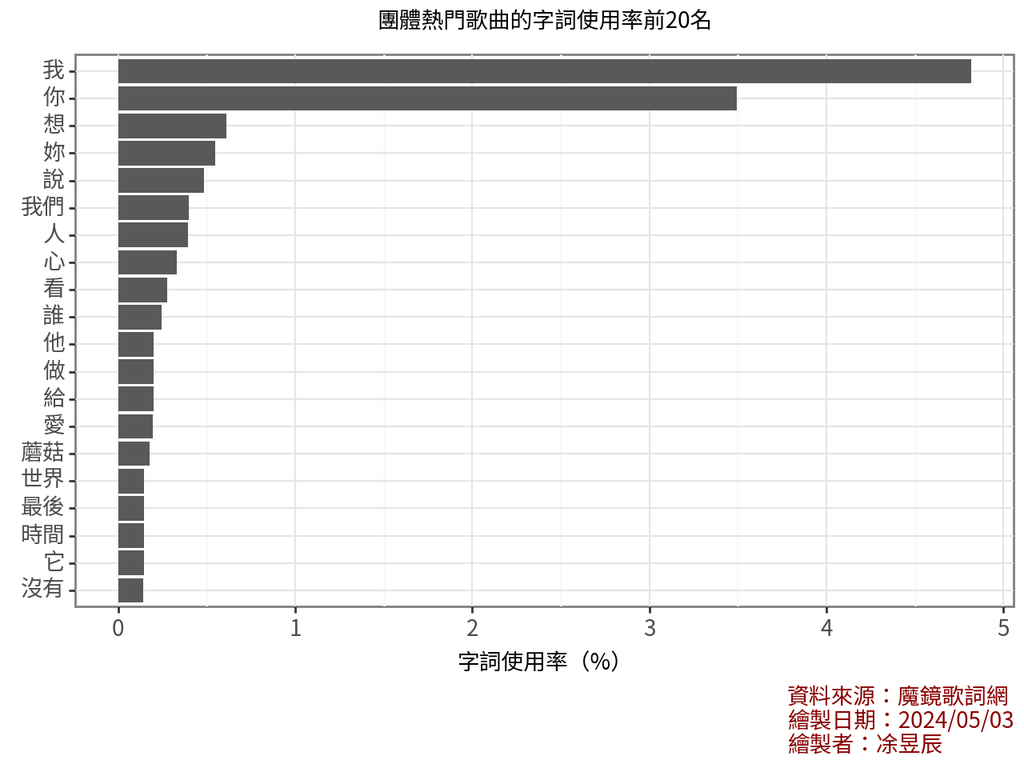

```
<Figure Size: (640 x 480)>
```

```python
#團體
fig4 = ggplot(x, aes(x='reorder(word, percent)',
                     y='percent')) +\
  geom_bar(stat='identity') +\
  labs(title='團體熱門歌曲的字詞使用率前20名',
       x='',
       y='字詞使用率（%）',
       caption='資料來源：魔鏡歌詞網\n繪製日期：'+pd.Timestamp("today").strftime("%Y/%m/%d")
      +'\n繪製者：凃昱辰')  +\
  coord_flip()+\
  theme_bw() +\
  theme(text=element_text(fontproperties=noto),
       plot_title=element_text(fontproperties=noto, ha='center'),
       plot_caption=element_text(fontproperties=noto,color='darkred',size=10,linespacing=1))
fig4
```

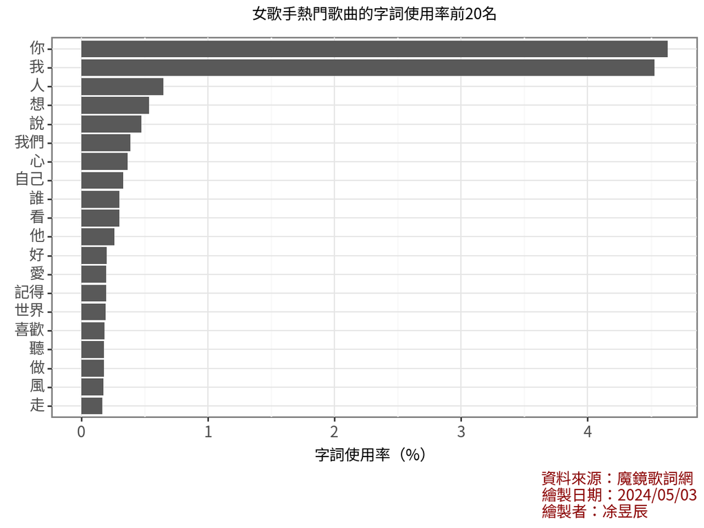

```
<Figure Size: (640 x 480)>
```

```python
#女歌手
fig5 = ggplot(y, aes(x='reorder(word, percent)',
                     y='percent')) +\
  geom_bar(stat='identity') +\
  labs(title='女歌手熱門歌曲的字詞使用率前20名',
       x='',
       y='字詞使用率（%）',
       caption='資料來源：魔鏡歌詞網\n繪製日期：'+pd.Timestamp("today").strftime("%Y/%m/%d")
      +'\n繪製者：凃昱辰')  +\
  coord_flip()+\
  theme_bw() +\
  theme(text=element_text(fontproperties=noto),
       plot_title=element_text(fontproperties=noto, ha='center'),
       plot_caption=element_text(fontproperties=noto,color='darkred',size=10,linespacing=1))
fig5
```

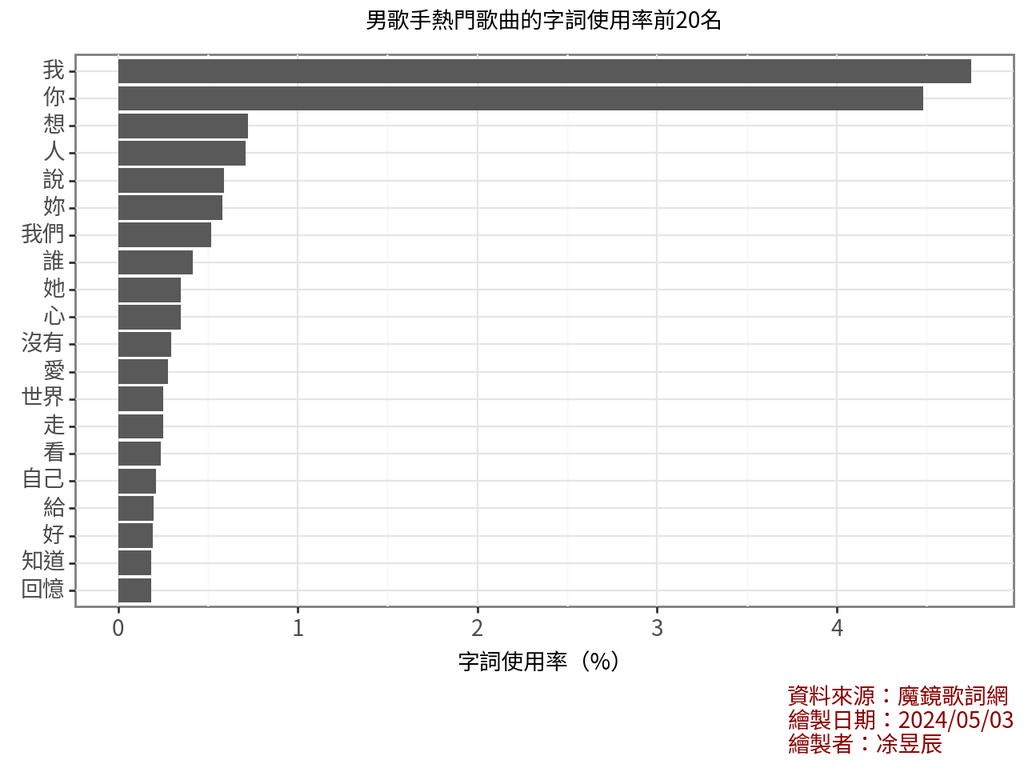

```
<Figure Size: (640 x 480)>
```

```python
#男歌手
fig6 = ggplot(z, aes(x='reorder(word, percent)',
                     y='percent')) +\
  geom_bar(stat='identity') +\
  labs(title='男歌手熱門歌曲的字詞使用率前20名',
       x='',
       y='字詞使用率（%）',
       caption='資料來源：魔鏡歌詞網\n繪製日期：'+pd.Timestamp("today").strftime("%Y/%m/%d")
      +'\n繪製者：凃昱辰')  +\
  coord_flip()+\
  theme_bw() +\
  theme(text=element_text(fontproperties=noto),
       plot_title=element_text(fontproperties=noto, ha='center'),
       plot_caption=element_text(fontproperties=noto,color='darkred',size=10,linespacing=1))
fig6
```

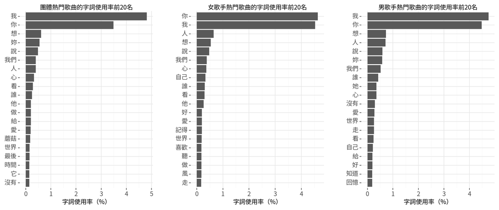

```python
#合併圖片
import patchworklib as pw
fg4=pw.load_ggplot(fig4, figsize=(3,4))
fg5=pw.load_ggplot(fig5, figsize=(3,4))
fg6=pw.load_ggplot(fig6, figsize=(3,4))
fig_percentage = (fg4|fg5|fg6)
fig_percentage
```

### 針對特定詞彙（你、我、想、我們、自己、愛）比較不同類別的比較

```python
#選取特定詞彙（你、我、想、我們、自己、愛）
selected_top = all_topwords[(all_topwords['word']=='我')|(all_topwords['word']=='你')|(all_topwords['word']=='我們')|(all_topwords['word']=='自己')|(all_topwords['word']=='想')|(all_topwords['word']=='愛')]
selected_top
```

|  | category | word | percent |
| --- | --- | --- | --- |
| 0 | 團體 | 我 | 4.817368 |
| 1 | 團體 | 你 | 3.492425 |
| 2 | 團體 | 想 | 0.610434 |
| 5 | 團體 | 我們 | 0.400984 |
| 13 | 團體 | 愛 | 0.194733 |
| 20 | 女歌手 | 你 | 4.631807 |
| 21 | 女歌手 | 我 | 4.526957 |
| 23 | 女歌手 | 想 | 0.537428 |
| 25 | 女歌手 | 我們 | 0.387305 |
| 27 | 女歌手 | 自己 | 0.330933 |
| 32 | 女歌手 | 愛 | 0.198031 |
| 40 | 男歌手 | 我 | 4.748035 |
| 41 | 男歌手 | 你 | 4.480157 |
| 42 | 男歌手 | 想 | 0.723259 |
| 46 | 男歌手 | 我們 | 0.517867 |
| 51 | 男歌手 | 愛 | 0.276461 |
| 55 | 男歌手 | 自己 | 0.209451 |

```python
#男歌手歌曲的「妳」、「你」使用率相加

condition_you = (all_topwords['category'] == '男歌手') & (all_topwords['word'] == '妳')
condition_you1 = (selected_top['category'] == '男歌手') & (selected_top['word'] == '你')


you = all_topwords.loc[condition_you, 'percent'].values[0]
you1 = selected_top.loc[condition_you1, 'percent'].values[0]

# 相加並寫入
selected_top.loc[condition_you1, 'percent'] = you + you1
```

```python
selected_top
```

|  | category | word | percent |
| --- | --- | --- | --- |
| 0 | 團體 | 我 | 4.817368 |
| 1 | 團體 | 你 | 3.492425 |
| 2 | 團體 | 想 | 0.610434 |
| 5 | 團體 | 我們 | 0.400984 |
| 13 | 團體 | 愛 | 0.194733 |
| 20 | 女歌手 | 你 | 4.631807 |
| 21 | 女歌手 | 我 | 4.526957 |
| 23 | 女歌手 | 想 | 0.537428 |
| 25 | 女歌手 | 我們 | 0.387305 |
| 27 | 女歌手 | 自己 | 0.330933 |
| 32 | 女歌手 | 愛 | 0.198031 |
| 40 | 男歌手 | 我 | 4.748035 |
| 41 | 男歌手 | 你 | 5.059559 |
| 42 | 男歌手 | 想 | 0.723259 |
| 46 | 男歌手 | 我們 | 0.517867 |
| 51 | 男歌手 | 愛 | 0.276461 |
| 55 | 男歌手 | 自己 | 0.209451 |

### 比較長條圖

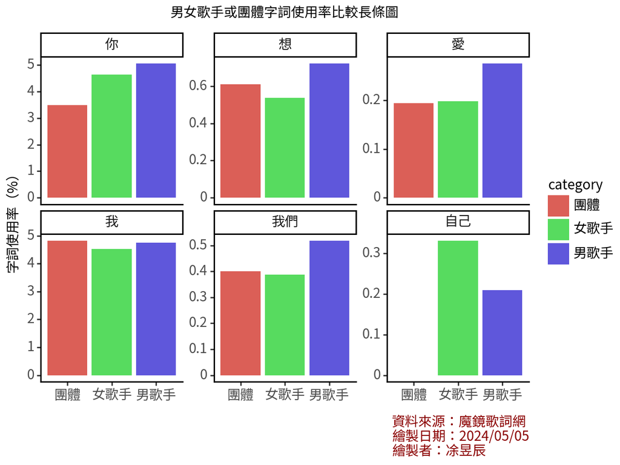

```
<Figure Size: (640 x 480)>
```

```python
fig_bar = ggplot(selected_top, aes(x='category',
                     y='percent',fill='category')) +\
  geom_bar(stat='identity')+\
  labs(title='男女歌手或團體字詞使用率比較長條圖',
       x='',
       y='字詞使用率（%）',
       caption='資料來源：魔鏡歌詞網\n繪製日期：'+pd.Timestamp("today").strftime("%Y/%m/%d")
      +'\n繪製者：凃昱辰')  +\
  theme_classic() +\
  theme(text=element_text(fontproperties=noto),
       plot_title=element_text(fontproperties=noto, ha='center'),
       plot_caption=element_text(fontproperties=noto,color='darkred',size=10,linespacing=1))+\
  facet_wrap('word',ncol=3,scales='free_y')
fig_bar
```

### 為了多了解字的使用情境，計算「愛」的連續n個詞（n-gram），會針對n = 2與n = 3來看

### 自訂函式：對特定詞彙抓取連續n的詞與計數

```python
import pandas as pd
from collections import Counter

# 抓取特定文字的 n-grams
def extract_and_count_specific_ngrams(text, target_char, n):
    ngrams = [text[i:i+n] for i in range(len(text) - n + 1) if text[i] == target_char]
    # n-gram當中不要有空格
    valid_ngrams = [ngram for ngram in ngrams if ' ' not in ngram]
    valid_ngrams = [ngram for ngram in valid_ngrams if len(ngram) == n]
    ngram_counts = Counter(valid_ngrams)
    return ngram_counts
```

### 對「愛」抓取連續2的詞與計數

```python
# 初始化空list
ngram_data = []

# 對「愛」抓取連續2的詞與計數
target_char = "愛"
n = 2  # 2-grams
for index, row in all.iterrows():
    category = row['Category']
    lyrics = row['Lyrics']
    ngram_counts = extract_and_count_specific_ngrams(lyrics, target_char, n)
    for ngram, frequency in ngram_counts.items():
        ngram_data.append({
            'category': category,
            'ngram': ngram,
            'frequency': frequency
        })

# 創建表格
bigram = pd.DataFrame(ngram_data)

# 顯示結果
print(bigram)
```

```
    category ngram  frequency
0        男歌手    愛上          1
1        男歌手    愛一          3
2        男歌手    愛本          1
3        男歌手    愛忘          4
4        男歌手    愛懂          3
..       ...   ...        ...
436       團體    愛妳          1
437       團體    愛郎          1
438       團體    愛，          1
439       團體    愛喝          1
440       團體    愛你          2

[441 rows x 3 columns]
```

### 抓取團體與男女歌手使用頻率前15名的連續2的詞

```python
bi=bigram.groupby(['category', 'ngram'])['frequency'].agg('sum').reset_index()
```

```python
bi_group = (bi[bi['category'] == '團體']
             .sort_values(by = ('frequency'), ascending=False)
            .head(15))
bi_group
```

|  | category | ngram | frequency |
| --- | --- | --- | --- |
| 9 | 團體 | 愛你 | 70 |
| 49 | 團體 | 愛的 | 59 |
| 31 | 團體 | 愛情 | 29 |
| 33 | 團體 | 愛我 | 28 |
| 53 | 團體 | 愛著 | 21 |
| 17 | 團體 | 愛啊 | 15 |
| 26 | 團體 | 愛尬 | 13 |
| 3 | 團體 | 愛上 | 9 |
| 11 | 團體 | 愛到 | 7 |
| 6 | 團體 | 愛人 | 7 |
| 56 | 團體 | 愛過 | 7 |
| 2 | 團體 | 愛ㄚ | 6 |
| 43 | 團體 | 愛沒 | 6 |
| 38 | 團體 | 愛是 | 5 |
| 7 | 團體 | 愛他 | 5 |

```python
bi_female = (bi[bi['category'] == '女歌手']
             .sort_values(by = ('frequency'), ascending=False)
            .head(15))
bi_female
```

|  | category | ngram | frequency |
| --- | --- | --- | --- |
| 100 | 女歌手 | 愛我 | 54 |
| 73 | 女歌手 | 愛你 | 46 |
| 113 | 女歌手 | 愛的 | 36 |
| 97 | 女歌手 | 愛情 | 34 |
| 127 | 女歌手 | 愛過 | 20 |
| 79 | 女歌手 | 愛到 | 13 |
| 121 | 女歌手 | 愛著 | 10 |
| 66 | 女歌手 | 愛上 | 10 |
| 68 | 女歌手 | 愛不 | 8 |
| 64 | 女歌手 | 愛 | 8 |
| 105 | 女歌手 | 愛會 | 7 |
| 65 | 女歌手 | 愛一 | 7 |
| 85 | 女歌手 | 愛嗎 | 6 |
| 120 | 女歌手 | 愛與 | 6 |
| 90 | 女歌手 | 愛寫 | 6 |

```python
bi_male = (bi[bi['category'] == '男歌手']
             .sort_values(by = ('frequency'), ascending=False)
            .head(15))
bi_male
```

|  | category | ngram | frequency |
| --- | --- | --- | --- |
| 143 | 男歌手 | 愛你 | 45 |
| 178 | 男歌手 | 愛的 | 38 |
| 160 | 男歌手 | 愛情 | 33 |
| 192 | 男歌手 | 愛過 | 32 |
| 136 | 男歌手 | 愛一 | 23 |
| 137 | 男歌手 | 愛上 | 19 |
| 163 | 男歌手 | 愛我 | 17 |
| 159 | 男歌手 | 愛恨 | 10 |
| 157 | 男歌手 | 愛得 | 10 |
| 151 | 男歌手 | 愛她 | 10 |
| 155 | 男歌手 | 愛就 | 9 |
| 186 | 男歌手 | 愛誰 | 7 |
| 161 | 男歌手 | 愛意 | 6 |
| 152 | 男歌手 | 愛妳 | 6 |
| 147 | 男歌手 | 愛只 | 5 |

### 對「愛」抓取連續3的詞與計數

```python
# 初始化空list
ngram_data = []

# 對「愛」抓取連續3的詞與計數
target_char = "愛"
n = 3  # 3-grams
for index, row in all.iterrows():
    category = row['Category']
    lyrics = row['Lyrics']
    ngram_counts = extract_and_count_specific_ngrams(lyrics, target_char, n)
    for ngram, frequency in ngram_counts.items():
        ngram_data.append({
            'category': category,
            'ngram': ngram,
            'frequency': frequency
        })

# 創建表格
trigram = pd.DataFrame(ngram_data)

# 顯示資料
print(trigram)
```

```
    category ngram  frequency
0        男歌手   愛上別          1
1        男歌手   愛一個          3
2        男歌手   愛本就          1
3        男歌手   愛忘了          4
4        男歌手   愛懂了          3
..       ...   ...        ...
421       團體   愛的地          4
422       團體   愛的慾          6
423       團體   愛，淒          1
424       團體   愛喝到          1
425       團體   愛你　          2

[426 rows x 3 columns]
```

```python
tri=trigram.groupby(['category', 'ngram'])['frequency'].agg('sum').reset_index()
```

```python
tri_group = (tri[tri['category'] == '團體']
             .sort_values(by = ('frequency'), ascending=False)
            .head(15))
tri_group
```

|  | category | ngram | frequency |
| --- | --- | --- | --- |
| 41 | 團體 | 愛尬欲 | 13 |
| 104 | 團體 | 愛著你 | 13 |
| 20 | 團體 | 愛你愛 | 8 |
| 90 | 團體 | 愛的動 | 8 |
| 99 | 團體 | 愛的親 | 6 |
| 66 | 團體 | 愛我的 | 6 |
| 89 | 團體 | 愛的人 | 6 |
| 63 | 團體 | 愛我你 | 6 |
| 91 | 團體 | 愛的南 | 6 |
| 10 | 團體 | 愛人就 | 6 |
| 96 | 團體 | 愛的慾 | 6 |
| 35 | 團體 | 愛太渴 | 4 |
| 102 | 團體 | 愛自由 | 4 |
| 43 | 團體 | 愛得太 | 4 |
| 92 | 團體 | 愛的地 | 4 |

```python
tri_female = (tri[tri['category'] == '女歌手']
             .sort_values(by = ('frequency'), ascending=False)
            .head(15))
tri_female
```

|  | category | ngram | frequency |
| --- | --- | --- | --- |
| 192 | 女歌手 | 愛我的 | 24 |
| 149 | 女歌手 | 愛你的 | 12 |
| 138 | 女歌手 | 愛你 | 9 |
| 250 | 女歌手 | 愛過我 | 7 |
| 157 | 女歌手 | 愛到妥 | 6 |
| 168 | 女歌手 | 愛寫出 | 6 |
| 133 | 女歌手 | 愛也是 | 6 |
| 248 | 女歌手 | 愛過你 | 5 |
| 214 | 女歌手 | 愛的人 | 5 |
| 185 | 女歌手 | 愛情碰 | 5 |
| 249 | 女歌手 | 愛過嗎 | 4 |
| 122 | 女歌手 | 愛一次 | 4 |
| 150 | 女歌手 | 愛偏開 | 4 |
| 181 | 女歌手 | 愛情曾 | 4 |
| 156 | 女歌手 | 愛到不 | 4 |

```python
tri_male = (tri[tri['category'] == '男歌手']
             .sort_values(by = ('frequency'), ascending=False)
            .head(15))
tri_male
```

|  | category | ngram | frequency |
| --- | --- | --- | --- |
| 289 | 男歌手 | 愛你的 | 11 |
| 268 | 男歌手 | 愛上你 | 11 |
| 263 | 男歌手 | 愛一個 | 10 |
| 265 | 男歌手 | 愛一次 | 10 |
| 327 | 男歌手 | 愛我嗎 | 8 |
| 309 | 男歌手 | 愛得多 | 7 |
| 360 | 男歌手 | 愛的那 | 6 |
| 313 | 男歌手 | 愛恨也 | 6 |
| 382 | 男歌手 | 愛過的 | 6 |
| 304 | 男歌手 | 愛就像 | 5 |
| 343 | 男歌手 | 愛溢出 | 5 |
| 275 | 男歌手 | 愛似浪 | 4 |
| 329 | 男歌手 | 愛拼才 | 4 |
| 278 | 男歌手 | 愛你不 | 4 |
| 300 | 男歌手 | 愛妳的 | 4 |

### 個別繪圖，並合併

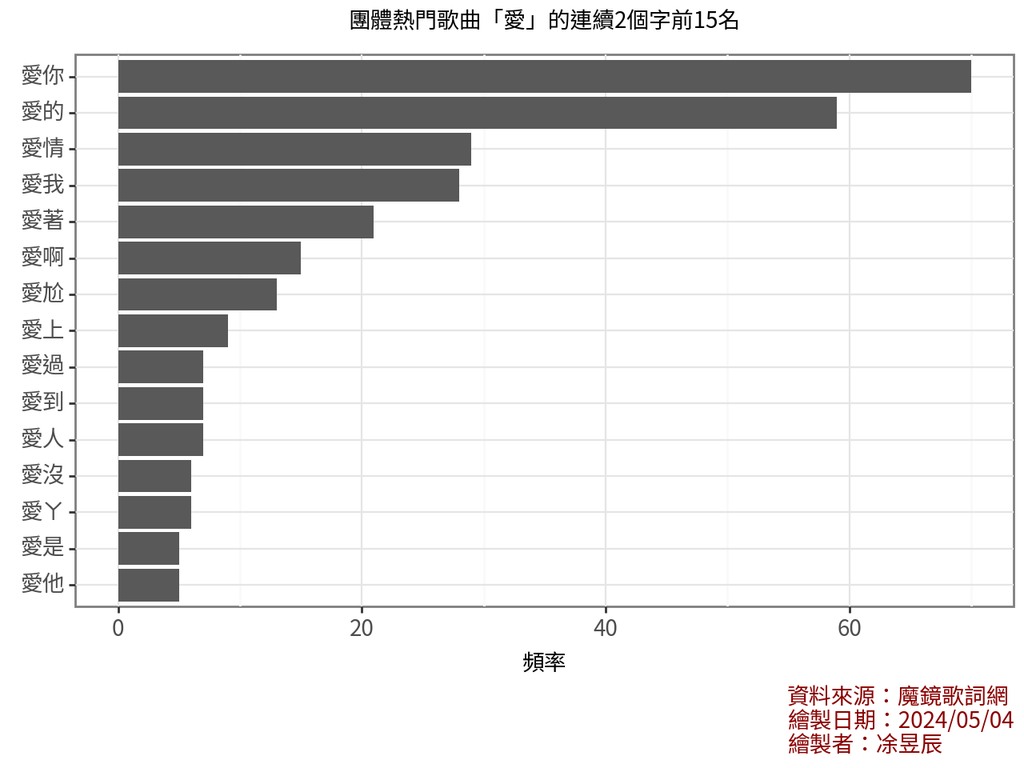

```
<Figure Size: (640 x 480)>
```

```python
fig7 = ggplot(bi_group, aes(x='reorder(ngram, frequency)',
                     y='frequency')) +\
  geom_bar(stat='identity') +\
  labs(title='團體熱門歌曲「愛」的連續2個字前15名',
       x='',
       y='頻率',
       caption='資料來源：魔鏡歌詞網\n繪製日期：'+pd.Timestamp("today").strftime("%Y/%m/%d")
      +'\n繪製者：凃昱辰')  +\
  coord_flip()+\
  theme_bw() +\
  theme(text=element_text(fontproperties=noto),
       plot_title=element_text(fontproperties=noto, ha='center'),
       plot_caption=element_text(fontproperties=noto,color='darkred',size=10,linespacing=1))
fig7
```

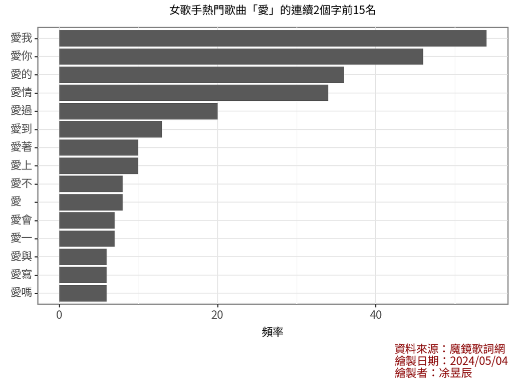

```
<Figure Size: (640 x 480)>
```

```python
fig8 = ggplot(bi_female, aes(x='reorder(ngram, frequency)',
                     y='frequency')) +\
  geom_bar(stat='identity') +\
  labs(title='女歌手熱門歌曲「愛」的連續2個字前15名',
       x='',
       y='頻率',
       caption='資料來源：魔鏡歌詞網\n繪製日期：'+pd.Timestamp("today").strftime("%Y/%m/%d")
      +'\n繪製者：凃昱辰')  +\
  coord_flip()+\
  theme_bw() +\
  theme(text=element_text(fontproperties=noto),
       plot_title=element_text(fontproperties=noto, ha='center'),
       plot_caption=element_text(fontproperties=noto,color='darkred',size=10,linespacing=1))
fig8
```

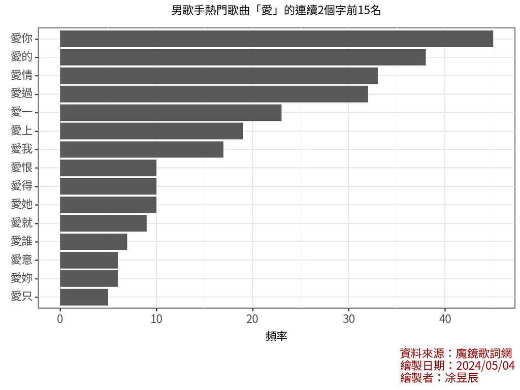

```
<Figure Size: (640 x 480)>
```

```python
fig9 = ggplot(bi_male, aes(x='reorder(ngram, frequency)',
                     y='frequency')) +\
  geom_bar(stat='identity') +\
  labs(title='男歌手熱門歌曲「愛」的連續2個字前15名',
       x='',
       y='頻率',
       caption='資料來源：魔鏡歌詞網\n繪製日期：'+pd.Timestamp("today").strftime("%Y/%m/%d")
      +'\n繪製者：凃昱辰')  +\
  coord_flip()+\
  theme_bw() +\
  theme(text=element_text(fontproperties=noto),
       plot_title=element_text(fontproperties=noto, ha='center'),
       plot_caption=element_text(fontproperties=noto,color='darkred',size=10,linespacing=1))
fig9
```

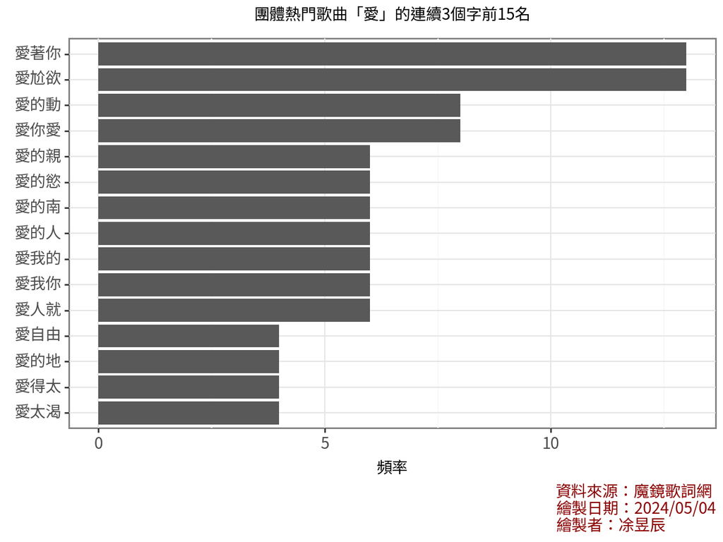

```
<Figure Size: (640 x 480)>
```

```python
fig10 = ggplot(tri_group, aes(x='reorder(ngram, frequency)',
                     y='frequency')) +\
  geom_bar(stat='identity') +\
  labs(title='團體熱門歌曲「愛」的連續3個字前15名',
       x='',
       y='頻率',
       caption='資料來源：魔鏡歌詞網\n繪製日期：'+pd.Timestamp("today").strftime("%Y/%m/%d")
      +'\n繪製者：凃昱辰')  +\
  coord_flip()+\
  theme_bw() +\
  theme(text=element_text(fontproperties=noto),
       plot_title=element_text(fontproperties=noto, ha='center'),
       plot_caption=element_text(fontproperties=noto,color='darkred',size=10,linespacing=1))
fig10
```

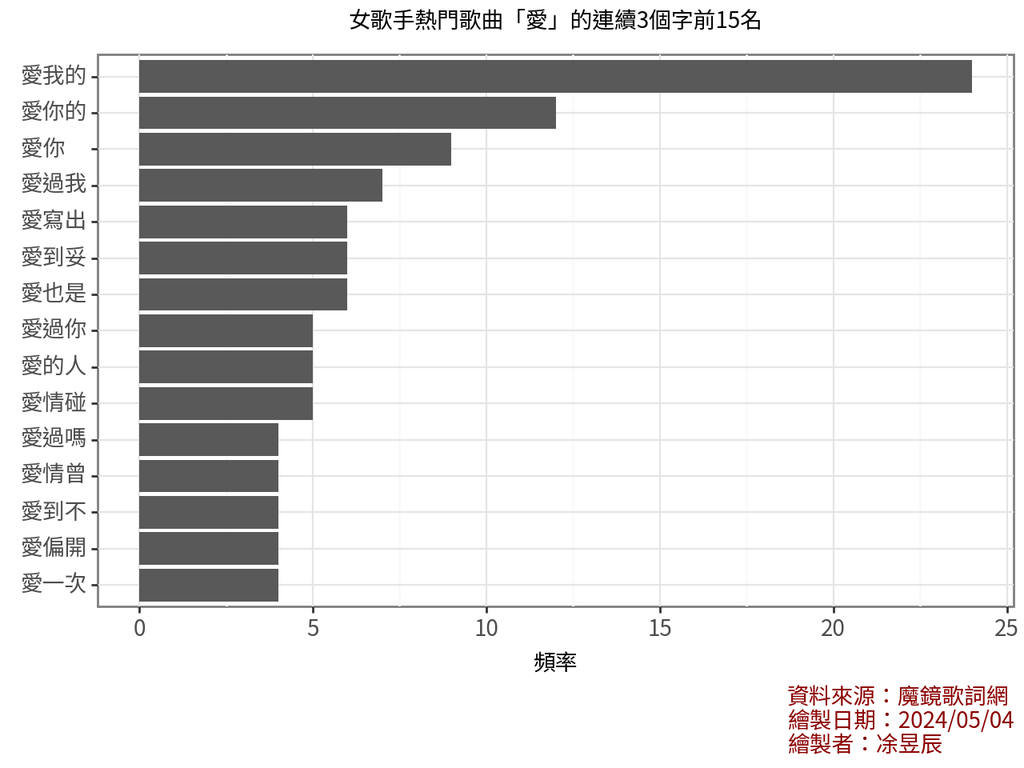

```
<Figure Size: (640 x 480)>
```

```python
fig11 = ggplot(tri_female, aes(x='reorder(ngram, frequency)',
                     y='frequency')) +\
  geom_bar(stat='identity') +\
  labs(title='女歌手熱門歌曲「愛」的連續3個字前15名',
       x='',
       y='頻率',
       caption='資料來源：魔鏡歌詞網\n繪製日期：'+pd.Timestamp("today").strftime("%Y/%m/%d")
      +'\n繪製者：凃昱辰')  +\
  coord_flip()+\
  theme_bw() +\
  theme(text=element_text(fontproperties=noto),
       plot_title=element_text(fontproperties=noto, ha='center'),
       plot_caption=element_text(fontproperties=noto,color='darkred',size=10,linespacing=1))
fig11
```

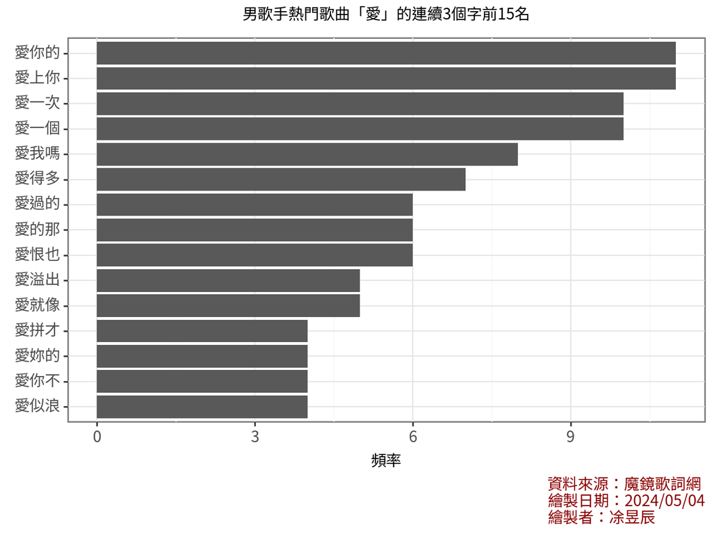

```
<Figure Size: (640 x 480)>
```

```python
fig12 = ggplot(tri_male, aes(x='reorder(ngram, frequency)',
                     y='frequency')) +\
  geom_bar(stat='identity') +\
  labs(title='男歌手熱門歌曲「愛」的連續3個字前15名',
       x='',
       y='頻率',
       caption='資料來源：魔鏡歌詞網\n繪製日期：'+pd.Timestamp("today").strftime("%Y/%m/%d")
      +'\n繪製者：凃昱辰')  +\
  coord_flip()+\
  theme_bw() +\
  theme(text=element_text(fontproperties=noto),
       plot_title=element_text(fontproperties=noto, ha='center'),
       plot_caption=element_text(fontproperties=noto,color='darkred',size=10,linespacing=1))
fig12
```

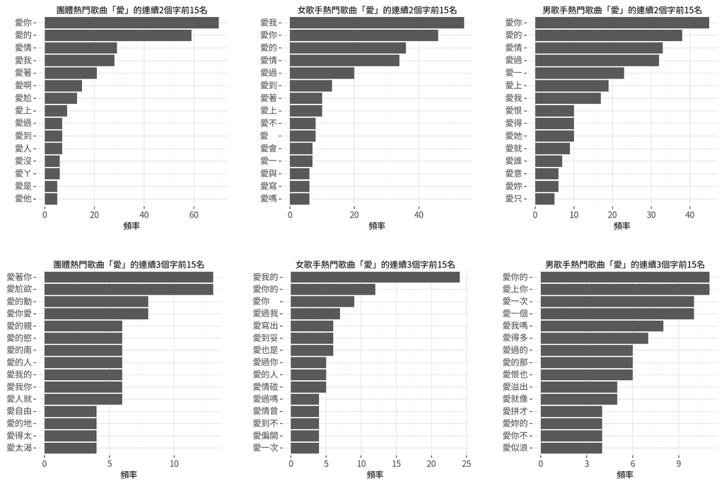

```python
#合併
import patchworklib as pw
fg7=pw.load_ggplot(fig7, figsize=(3,3))
fg8=pw.load_ggplot(fig8, figsize=(3,3))
fg9=pw.load_ggplot(fig9, figsize=(3,3))
fg10=pw.load_ggplot(fig10, figsize=(3,3))
fg11=pw.load_ggplot(fig11, figsize=(3,3))
fg12=pw.load_ggplot(fig12, figsize=(3,3))
fig_ngram = (fg7|fg8|fg9)/(fg10|fg11|fg12)
fig_ngram
```